# wk4-hw`kenwan`bayes

# Biomial output with two groups

Data are panel data containing columns: sex, race, age, education, state and y. The output y is the binary version of the original data. It reflects opinion (positive-1, negative-0) about President Barak Obama during his 2012 campaign for reelection.

Consider problem of identifying responses of two gender groups (column sex).

Decide what is the right model and analyze it using JAGS.

Consider different prior distributions.

### Load in data

```r
myData = read.csv(paste0(dataPath,"wk4/MScA_32014_BayesianMethods_CourseProjectData.csv"))
head(myData)
```

```
##      sex    race   age       education state y
## 1 1.Male 1.White 18-24     1.NoCollege    GA 0
## 2 1.Male 1.White 25-34     1.NoCollege    AZ 0
## 3 1.Male 1.White 25-34   2.SomeCollege    SD 0
## 4 1.Male 1.White 18-24 3.CollegeOrMore    SC 0
## 5 1.Male 1.White 18-24 3.CollegeOrMore    SC 0
## 6 1.Male 1.White 18-24 3.CollegeOrMore    SC 0
```

```r
dim(myData)
```

```
## [1] 23223     6
```

```r
 #positive
sum(myData$y)
```

```
## [1] 8514
```

```r
(dataList<-list(y=myData$y,Ntotal=length(myData$y)))
```

[output not shown]

[output cut: 673 more lines]

```r
y<-myData$y
(Ntotal<-length(y))
```

```
## [1] 23223
```

Let’s use a binomial model.

```r
# model init
modelString="
model {
  for (i in 1:length(Ntotal)) {
    y[i]~dbern(theta)
  }
  theta~dbeta(1,1)
}
"

writeLines(modelString,con=paste0(dataPath,"wk4/Tempmodel.txt"))
```

Initialize MCMC.

```r
MLE=sum(myData$y)/length(myData$y)
(init1<-MLE)
```

```
## [1] 0.3666193
```

```r
(init2<-MLE*(1+.01))
```

```
## [1] 0.3702855
```

```r
(init3<-MLE*(1-.01))
```

```
## [1] 0.3629531
```

```r
# fx
initsList<-function(){
  thetaInit<-sample(c(init1,init2,init3),1,replace=T)
  return(list(theta=thetaInit))
}

initsList()
```

```
## $theta
## [1] 0.3702855
```

Now JAGS

```r
jagsModel<-jags.model(file="Tempmodel.txt",data=dataList,n.chains=3,n.adapt=500)
```

Run

```r
update(jagsModel,n.iter=600)

codaSamples<-coda.samples(jagsModel,variable.names=c("theta"),n.iter=3334)
list.samplers(jagsModel)
```

```
## $`bugs::ConjugateBeta`
## [1] "theta"
```

```r
head(codaSamples)
```

```
## [[1]]
## Markov Chain Monte Carlo (MCMC) output:
## Start = 601
## End = 607
## Thinning interval = 1
##          theta
## [1,] 0.1213590
## [2,] 0.6772252
## [3,] 0.3596347
## [4,] 0.3044383
## [5,] 0.3921546
## [6,] 0.3243165
## [7,] 0.3022703
##
## [[2]]
## Markov Chain Monte Carlo (MCMC) output:
## Start = 601
## End = 607
## Thinning interval = 1
##          theta
## [1,] 0.2304206
## [2,] 0.1528788
## [3,] 0.0573860
## [4,] 0.3129044
## [5,] 0.5480119
## [6,] 0.6407252
## [7,] 0.1380623
##
## [[3]]
## Markov Chain Monte Carlo (MCMC) output:
## Start = 601
## End = 607
## Thinning interval = 1
##           theta
## [1,] 0.01211703
## [2,] 0.63642603
## [3,] 0.19173860
## [4,] 0.52285702
## [5,] 0.41412858
## [6,] 0.47666132
## [7,] 0.49672403
##
## attr(,"class")
## [1] "mcmc.list"
```

```r
summary(codaSamples)
```

```
##
## Iterations = 601:3934
## Thinning interval = 1
## Number of chains = 3
## Sample size per chain = 3334
##
## 1. Empirical mean and standard deviation for each variable,
##    plus standard error of the mean:
##
##           Mean             SD       Naive SE Time-series SE
##       0.333099       0.235615       0.002356       0.002378
##
## 2. Quantiles for each variable:
##
##    2.5%     25%     50%     75%   97.5%
## 0.01183 0.13380 0.29234 0.50441 0.84075
```

More diagnostics.

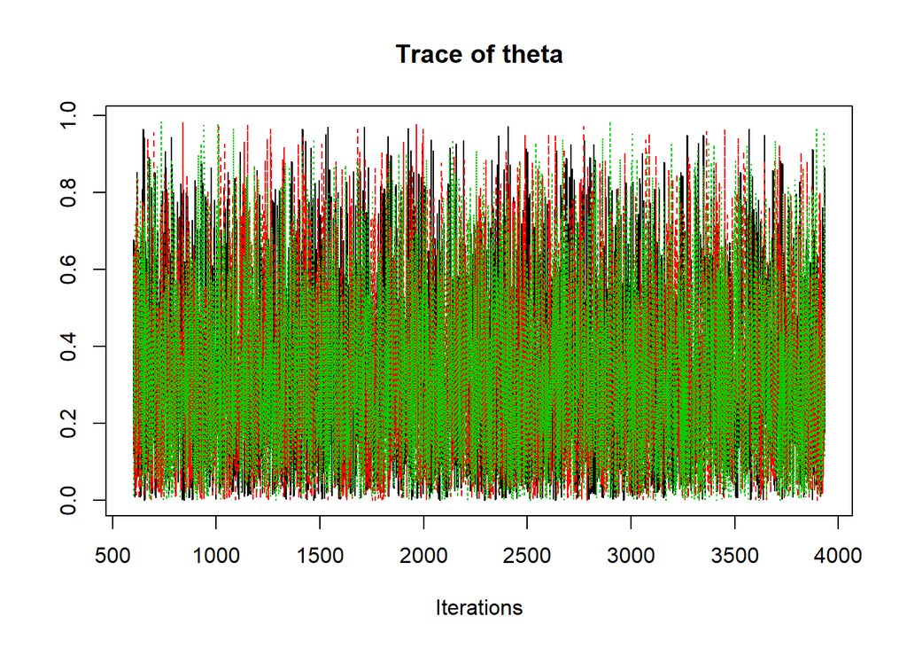

```r
coda::traceplot(codaSamples)
```

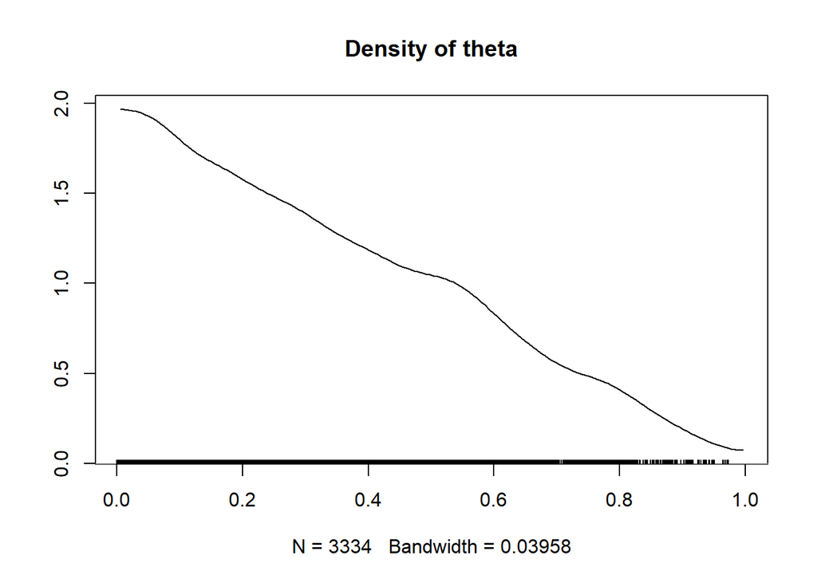

```r
densplot(codaSamples)
```

We can see in the density plot that we ahve no gaussian shape to theta.

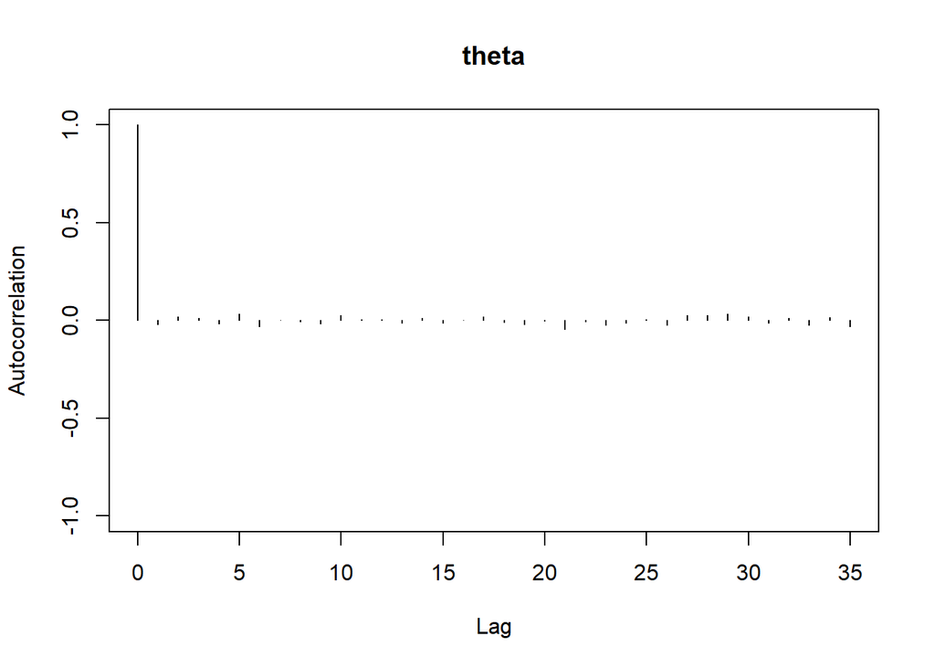

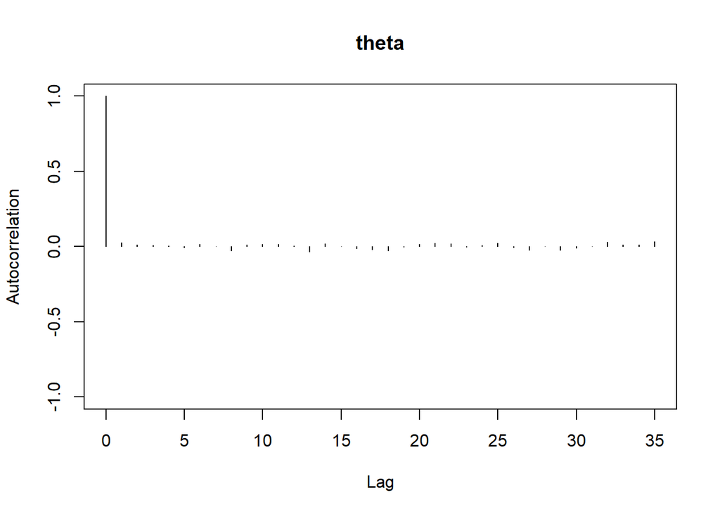

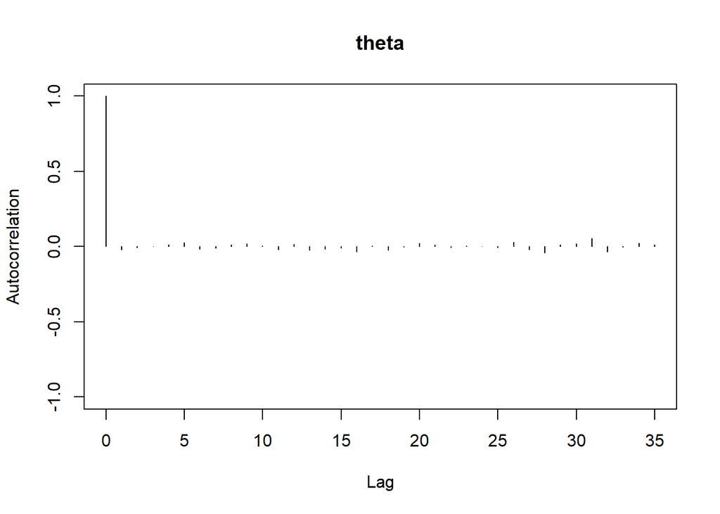

```r
autocorr.plot(codaSamples,ask=F)
```

```r
effectiveSize(codaSamples)
```

```
##    theta
## 9828.257
```

Don’t see autocvorrelation, though, so don’t believe we havbe conmvergence issues.

```r
gelman.diag(codaSamples)
```

```
## Potential scale reduction factors:
##
##       Point est. Upper C.I.
## theta          1          1
```

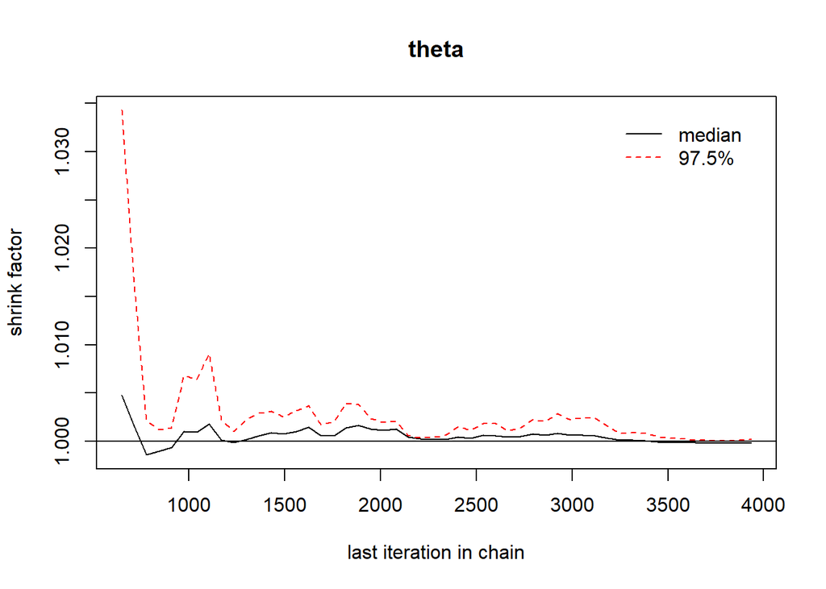

```r
gelman.plot(codaSamples)
```

Gelman shrinkage suggests convergence was fine as well.

```r
lapply(codaSamples,mean)
```

```
## [[1]]
## [1] 0.338489
##
## [[2]]
## [1] 0.3286866
##
## [[3]]
## [1] 0.3321222
```

```r
sum(y)/Ntotal
```

```
## [1] 0.3666193
```

```r
# posterior densities vs theortical
(l<-min(unlist(codaSamples))-.05)
```

```
## [1] -0.04995079
```

```r
(h<-max(unlist(codaSamples))+.05)
```

```
## [1] 1.03551
```

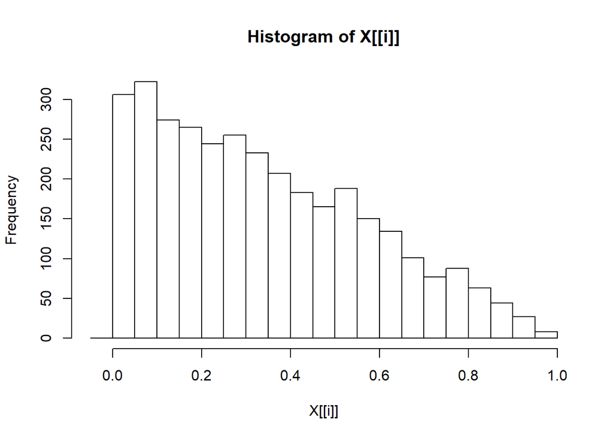

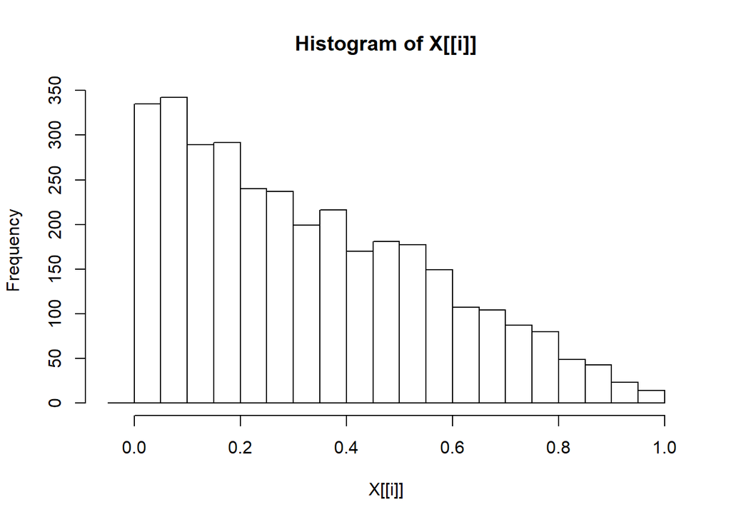

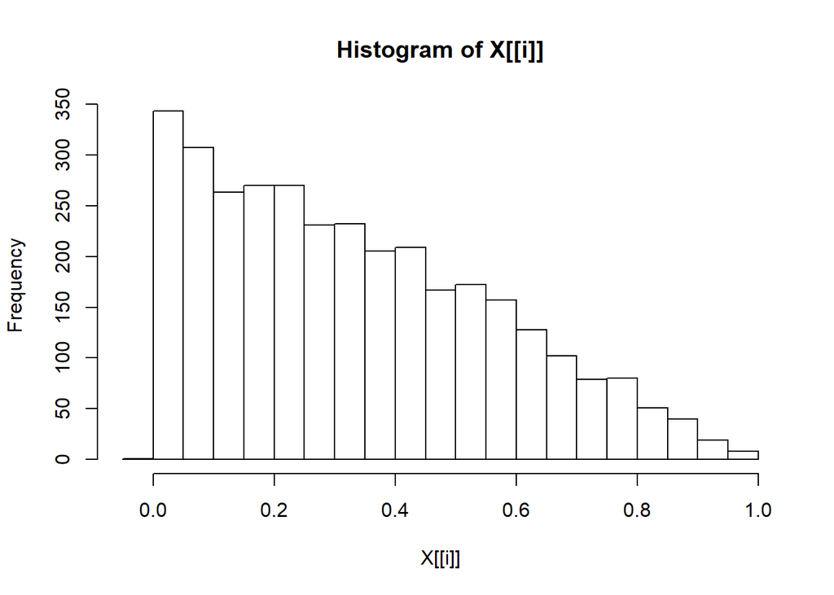

```r
histBreaks<-seq(l,h,by=.05)
postHist<-lapply(codaSamples,hist,breaks=histBreaks)
```

# We can see that our simple binomial breaks down.

Most likely we have two different groups (republican vs democratic). They have the same prior, but diufferent thetas.

However we don’t have that information. Let’s see if one based solely upon race would work.

```r
unique(myData$race)
```

```
## [1] 1.White    2.Black    3.Hispanic 4.Other
## Levels: 1.White 2.Black 3.Hispanic 4.Other
```

```r
unique(as.numeric(myData$race))
```

```
## [1] 1 2 3 4
```

```r
unique(myData$education)
```

```
## [1] 1.NoCollege     2.SomeCollege   3.CollegeOrMore
## Levels: 1.NoCollege 2.SomeCollege 3.CollegeOrMore
```

```r
#string
(s<-as.numeric(myData$race))
```

[output not shown]

[output cut: 669 more lines]

```r
(Nsubj=length(unique(s)))
```

```
## [1] 4
```

```r
(dataList<-list(y=y,s=s,Ntotal=Ntotal,Nsubj=Nsubj))
```

[output not shown]

[output cut: 1362 more lines]

```r
# model

modelString = "
model {
  for ( i in 1:Ntotal ) {
    y[i] ~ dbern( theta[s[i]] )
  }
  for ( sIdx in 1:Nsubj ) {      # Different thetas from same prior
    theta[sIdx] ~ dbeta( 1 , 1 ) # N.B.: 2,2 prior; change as appropriate.
  }
}
" # close quote for modelString
writeLines( modelString , con="TEMP2model.txt" )
```

Initialize MCMC.

```r
MLE=sum(myData$y)/length(myData$y)
(init1<-MLE)
```

```
## [1] 0.3666193
```

```r
(init2<-MLE*(1+.01))
```

```
## [1] 0.3702855
```

```r
(init3<-MLE*(1-.01))
```

```
## [1] 0.3629531
```

```r
# fx
initsList<-function(){
  thetaInit<-sample(c(init1,init2,init3),1,replace=T)
  return(list(theta=thetaInit))
}

initsList()
```

```
## $theta
## [1] 0.3629531
```

Now JAGS

```r
jagsModel<-jags.model(file="TEMP2model.txt",data=dataList,n.chains=3,n.adapt=500)
```

Run

```r
update(jagsModel,n.iter=600)

codaSamples<-coda.samples(jagsModel,variable.names=c("theta"),n.iter=3334)
list.samplers(jagsModel)
```

```
## $`bugs::ConjugateBeta`
## [1] "theta[4]"
##
## $`bugs::ConjugateBeta`
## [1] "theta[3]"
##
## $`bugs::ConjugateBeta`
## [1] "theta[2]"
##
## $`bugs::ConjugateBeta`
## [1] "theta[1]"
```

```r
head(codaSamples)
```

```
## [[1]]
## Markov Chain Monte Carlo (MCMC) output:
## Start = 601
## End = 607
## Thinning interval = 1
##       theta[1]  theta[2]  theta[3]  theta[4]
## [1,] 0.3030885 0.9340568 0.5313925 0.5033952
## [2,] 0.3067324 0.9560662 0.4924604 0.4931066
## [3,] 0.3038674 0.9524611 0.5382909 0.5083937
## [4,] 0.2996785 0.9321132 0.4955894 0.4999585
## [5,] 0.3066848 0.9456557 0.5376985 0.5005850
## [6,] 0.3030603 0.9454279 0.5243446 0.5069534
## [7,] 0.3030202 0.9453276 0.5304038 0.5027273
##
## [[2]]
## Markov Chain Monte Carlo (MCMC) output:
## Start = 601
## End = 607
## Thinning interval = 1
##       theta[1]  theta[2]  theta[3]  theta[4]
## [1,] 0.3065541 0.9428559 0.5350566 0.5053597
## [2,] 0.3055860 0.9431563 0.5136666 0.5168950
## [3,] 0.2999482 0.9388451 0.5057221 0.5360391
## [4,] 0.3078730 0.9323992 0.5411187 0.5154892
## [5,] 0.3056800 0.9417376 0.5358905 0.5107522
## [6,] 0.3021780 0.9377043 0.5465552 0.5041402
## [7,] 0.3063987 0.9422419 0.5016009 0.5052771
##
## [[3]]
## Markov Chain Monte Carlo (MCMC) output:
## Start = 601
## End = 607
## Thinning interval = 1
##       theta[1]  theta[2]  theta[3]  theta[4]
## [1,] 0.2972942 0.9390375 0.5273351 0.5137896
## [2,] 0.3054516 0.9408742 0.5238374 0.5076798
## [3,] 0.3028822 0.9398501 0.5087252 0.5194587
## [4,] 0.2953563 0.9482380 0.5043649 0.4967933
## [5,] 0.3019010 0.9417849 0.5105387 0.5039694
## [6,] 0.3057711 0.9575114 0.5173636 0.5057964
## [7,] 0.2988699 0.9445329 0.5198818 0.5073096
##
## attr(,"class")
## [1] "mcmc.list"
```

```r
summary(codaSamples)
```

```
##
## Iterations = 601:3934
## Thinning interval = 1
## Number of chains = 3
## Sample size per chain = 3334
##
## 1. Empirical mean and standard deviation for each variable,
##    plus standard error of the mean:
##
##            Mean       SD  Naive SE Time-series SE
## theta[1] 0.3032 0.003271 3.271e-05      3.271e-05
## theta[2] 0.9418 0.005944 5.944e-05      5.770e-05
## theta[3] 0.5268 0.016371 1.637e-04      1.637e-04
## theta[4] 0.5091 0.014156 1.416e-04      1.494e-04
##
## 2. Quantiles for each variable:
##
##            2.5%    25%    50%    75%  97.5%
## theta[1] 0.2968 0.3010 0.3032 0.3054 0.3096
## theta[2] 0.9298 0.9379 0.9420 0.9459 0.9530
## theta[3] 0.4949 0.5157 0.5269 0.5377 0.5596
## theta[4] 0.4820 0.4994 0.5090 0.5186 0.5372
```

White (group1) has a very different mean theta as does black.

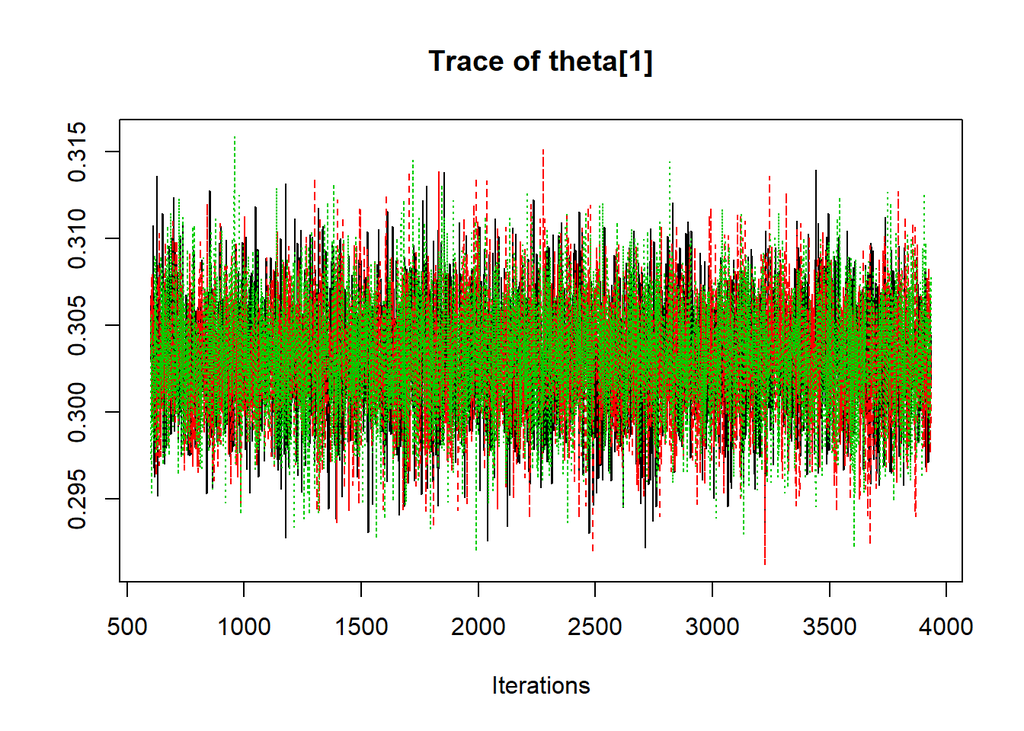

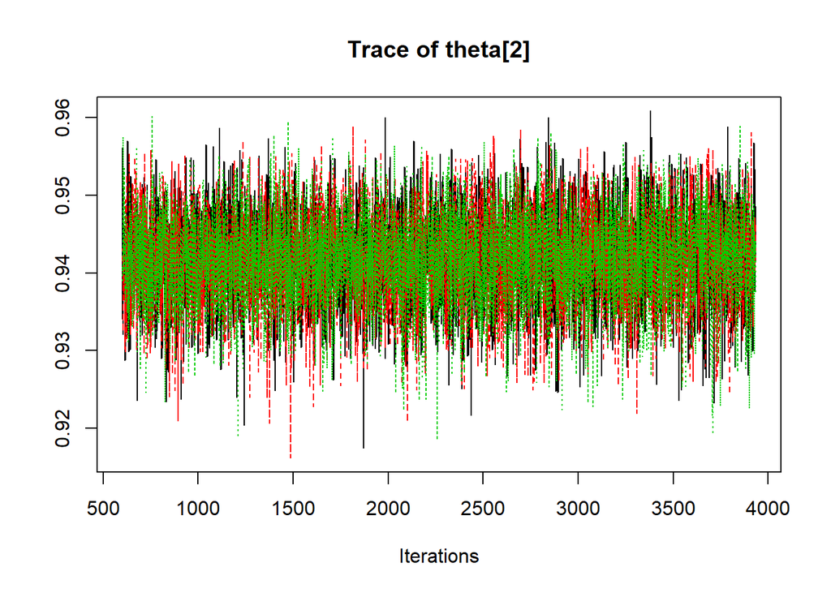

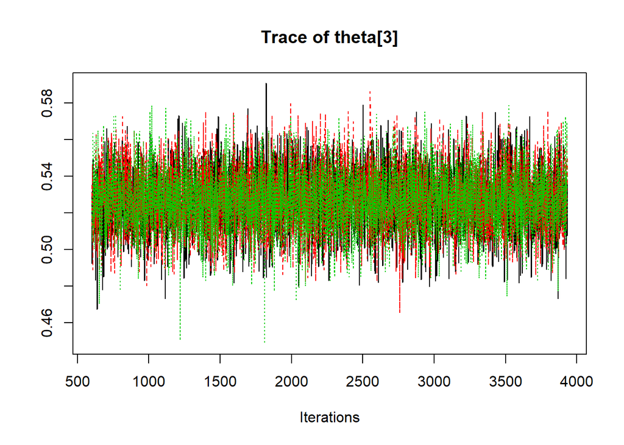

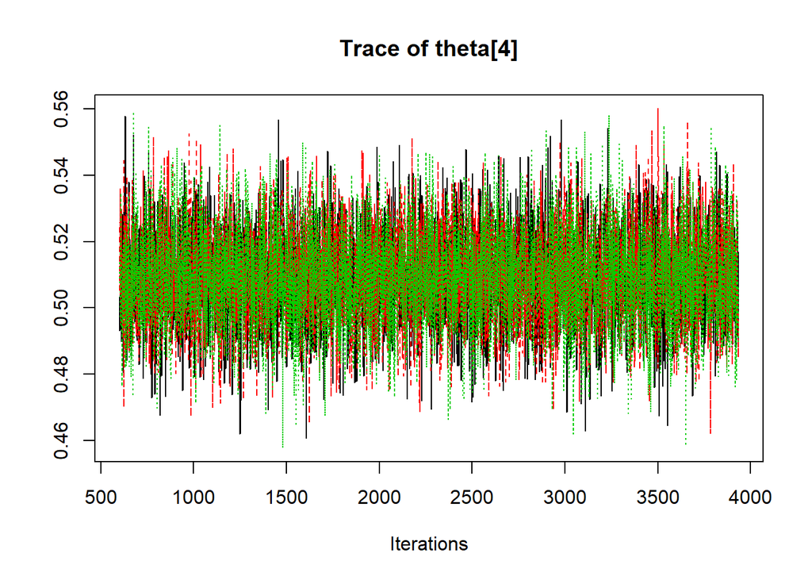

```r
coda::traceplot(codaSamples)
```

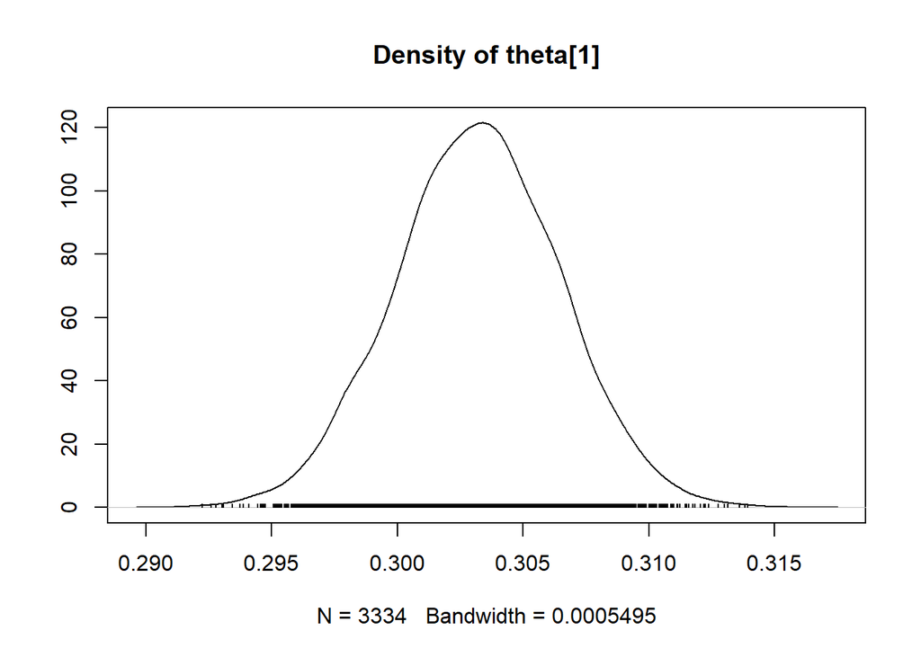

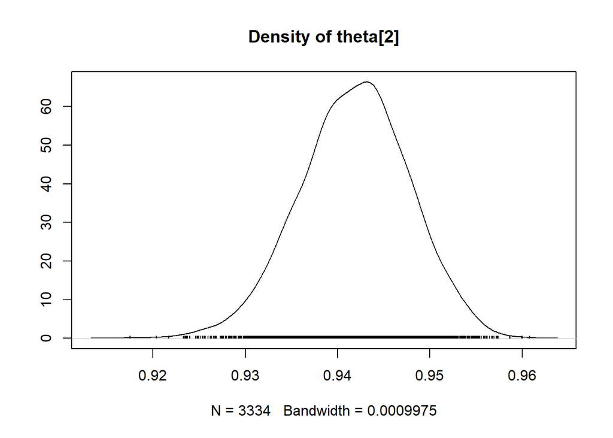

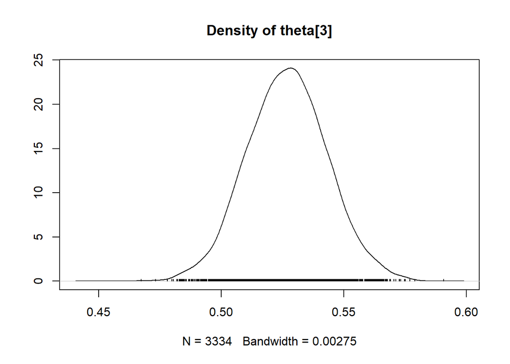

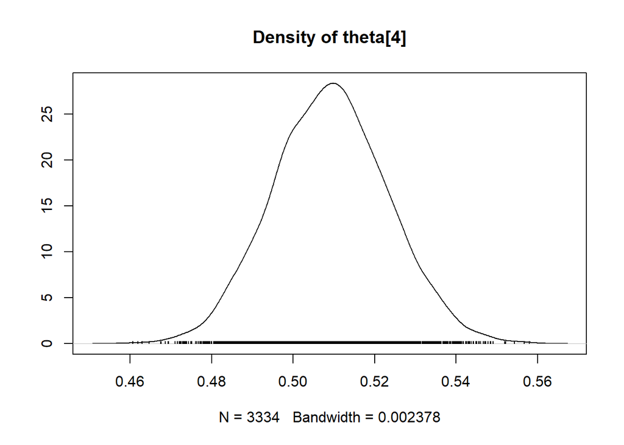

```r
densplot(codaSamples)
```

Shape is better now too.

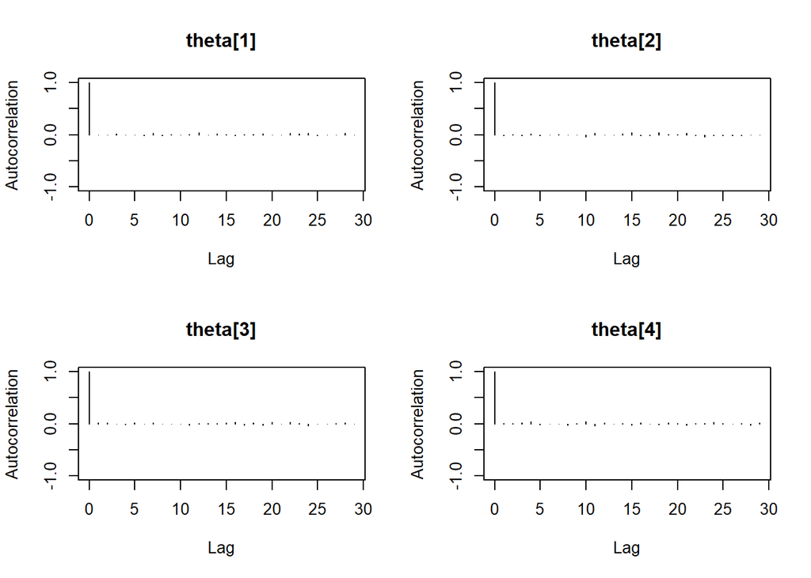

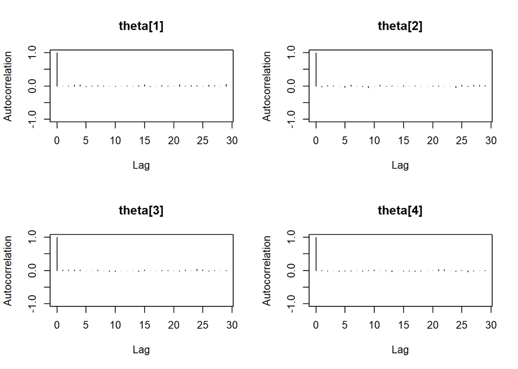

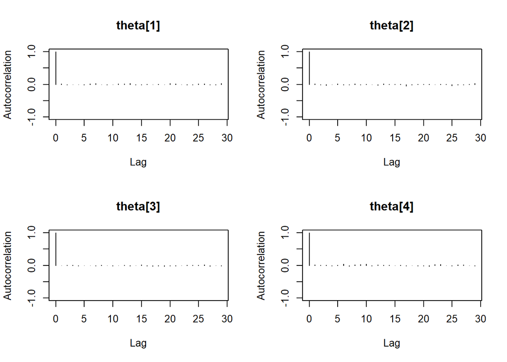

```r
autocorr.plot(codaSamples,ask=F)
```

```r
effectiveSize(codaSamples)
```

```
##  theta[1]  theta[2]  theta[3]  theta[4]
## 10002.000 10689.456 10002.000  9193.502
```

Don’t see autocvorrelation, though, so don’t believe we havbe conmvergence issues.

```r
gelman.diag(codaSamples)
```

```
## Potential scale reduction factors:
##
##          Point est. Upper C.I.
## theta[1]          1          1
## theta[2]          1          1
## theta[3]          1          1
## theta[4]          1          1
##
## Multivariate psrf
##
## 1
```

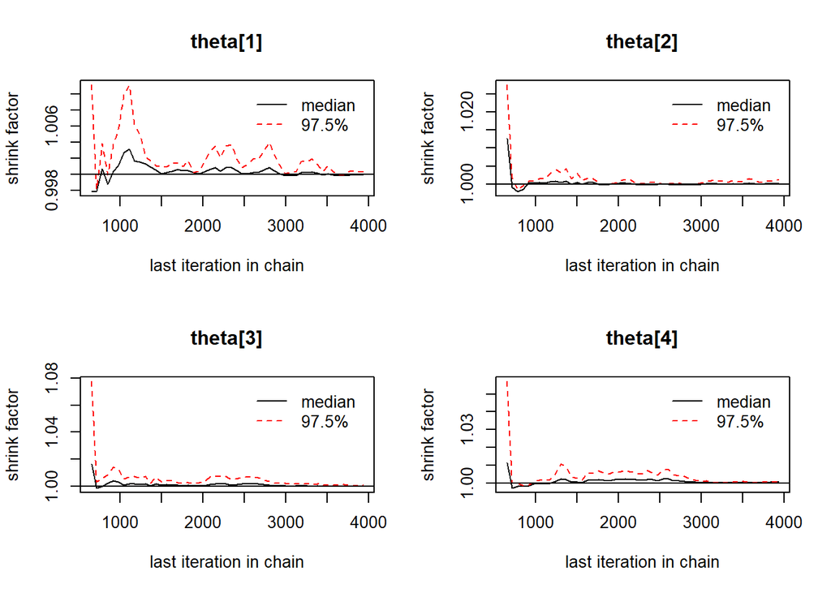

```r
gelman.plot(codaSamples)
```

Gelman shrinkage suggests convergence was fine as well.

```r
matrix(unlist(lapply(codaSamples,function(z) apply(z,2,mean))),ncol=3)
```

```
##           [,1]      [,2]      [,3]
## [1,] 0.3031530 0.3032098 0.3032070
## [2,] 0.9418897 0.9417659 0.9417381
## [3,] 0.5266226 0.5273744 0.5265507
## [4,] 0.5090243 0.5093565 0.5089986
```

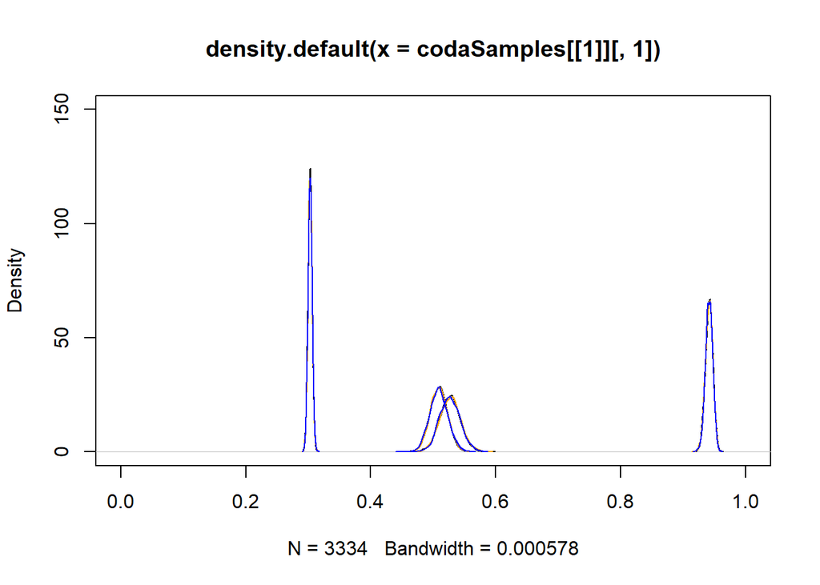

```r
plot(density(codaSamples[[1]][,1]),xlim=c(0,1),ylim=c(0,150))
lines(density(codaSamples[[1]][,2]))
lines(density(codaSamples[[1]][,3]))
lines(density(codaSamples[[1]][,4]))


lines(density(codaSamples[[2]][,1]),col="orange")
lines(density(codaSamples[[2]][,2]),col="orange")
lines(density(codaSamples[[2]][,3]),col="orange")
lines(density(codaSamples[[2]][,4]),col="orange")

lines(density(codaSamples[[3]][,1]),col="blue")
lines(density(codaSamples[[3]][,2]),col="blue")
lines(density(codaSamples[[3]][,3]),col="blue")
lines(density(codaSamples[[3]][,4]),col="blue")
```

HDI

```r
(HDIofChainsHierarchi<-lapply(codaSamples,function(z) cbind(Theta1=HDIofMCMC(codaSamples[[1]][,1]),                                                   Theta2=HDIofMCMC(codaSamples[[1]][,2]),Theta3=HDIofMCMC(codaSamples[[1]][,3]),Theta4=HDIofMCMC(codaSamples[[1]][,4]))))
```

```
## [[1]]
##         Theta1   Theta2    Theta3    Theta4
## [1,] 0.2970161 0.930312 0.4963746 0.4818544
## [2,] 0.3097525 0.953644 0.5604941 0.5357983
##
## [[2]]
##         Theta1   Theta2    Theta3    Theta4
## [1,] 0.2970161 0.930312 0.4963746 0.4818544
## [2,] 0.3097525 0.953644 0.5604941 0.5357983
##
## [[3]]
##         Theta1   Theta2    Theta3    Theta4
## [1,] 0.2970161 0.930312 0.4963746 0.4818544
## [2,] 0.3097525 0.953644 0.5604941 0.5357983
```

### lastly we’ll apply different priors

```r
# model

modelString = "
model {
  for ( i in 1:Ntotal ) {
    y[i] ~ dbern( theta[s[i]] )
  }
  for ( sIdx in 1:Nsubj ) {      # Different thetas from same prior
    theta[sIdx] ~ dbeta( 2 , 2 ) # N.B.: 2,2 prior; change as appropriate.
  }
}
" # close quote for modelString
writeLines( modelString , con="TEMP3model.txt" )
```

Initialize MCMC. different MLE starts as well.

```r
MLE=sum(myData$y)/length(myData$y)
(init1<-MLE)
```

```
## [1] 0.3666193
```

```r
(init2<-MLE*(1+.5))
```

```
## [1] 0.5499289
```

```r
(init3<-MLE*(1-.5))
```

```
## [1] 0.1833096
```

```r
# fx
initsList<-function(){
  thetaInit<-sample(c(init1,init2,init3),1,replace=T)
  return(list(theta=thetaInit))
}

initsList()
```

```
## $theta
## [1] 0.1833096
```

Now JAGS

```r
jagsModel<-jags.model(file="TEMP3model.txt",data=dataList,n.chains=3,n.adapt=500)
```

Run

```r
update(jagsModel,n.iter=600)

codaSamples2<-coda.samples(jagsModel,variable.names=c("theta"),n.iter=3334)
list.samplers(jagsModel)
```

```
## $`bugs::ConjugateBeta`
## [1] "theta[4]"
##
## $`bugs::ConjugateBeta`
## [1] "theta[3]"
##
## $`bugs::ConjugateBeta`
## [1] "theta[2]"
##
## $`bugs::ConjugateBeta`
## [1] "theta[1]"
```

```r
head(codaSamples2)
```

```
## [[1]]
## Markov Chain Monte Carlo (MCMC) output:
## Start = 601
## End = 607
## Thinning interval = 1
##       theta[1]  theta[2]  theta[3]  theta[4]
## [1,] 0.3008888 0.9441205 0.5096466 0.5134515
## [2,] 0.2983233 0.9321275 0.5257460 0.5104000
## [3,] 0.3065480 0.9328446 0.5452737 0.4956012
## [4,] 0.3082422 0.9314006 0.5181317 0.5188223
## [5,] 0.3038987 0.9454740 0.5336088 0.4941717
## [6,] 0.3072468 0.9356794 0.4874112 0.5076686
## [7,] 0.3054155 0.9387204 0.5539516 0.4903971
##
## [[2]]
## Markov Chain Monte Carlo (MCMC) output:
## Start = 601
## End = 607
## Thinning interval = 1
##       theta[1]  theta[2]  theta[3]  theta[4]
## [1,] 0.3030158 0.9531507 0.4945028 0.5252954
## [2,] 0.3024704 0.9466159 0.5173050 0.4991904
## [3,] 0.3078422 0.9356413 0.5169022 0.5137349
## [4,] 0.3026312 0.9354807 0.5039927 0.4963363
## [5,] 0.3018021 0.9510659 0.5146849 0.5129824
## [6,] 0.3005368 0.9354169 0.5462577 0.5221503
## [7,] 0.3014969 0.9397634 0.5333465 0.5072619
##
## [[3]]
## Markov Chain Monte Carlo (MCMC) output:
## Start = 601
## End = 607
## Thinning interval = 1
##       theta[1]  theta[2]  theta[3]  theta[4]
## [1,] 0.2979898 0.9415313 0.5267408 0.5256390
## [2,] 0.3054920 0.9423810 0.5623973 0.5083398
## [3,] 0.3053512 0.9535714 0.5412924 0.4943838
## [4,] 0.3030128 0.9507765 0.5263734 0.4678860
## [5,] 0.3058773 0.9387976 0.4892401 0.5210938
## [6,] 0.3044001 0.9384094 0.5421302 0.4970130
## [7,] 0.3011772 0.9456219 0.5028576 0.4910047
##
## attr(,"class")
## [1] "mcmc.list"
```

Let’s compare the two runs: run one with 1,1 prior of beta distribution and the second with 2,2 and wider MLE inits.

```r
#run1
summary(codaSamples)
```

```
##
## Iterations = 601:3934
## Thinning interval = 1
## Number of chains = 3
## Sample size per chain = 3334
##
## 1. Empirical mean and standard deviation for each variable,
##    plus standard error of the mean:
##
##            Mean       SD  Naive SE Time-series SE
## theta[1] 0.3032 0.003271 3.271e-05      3.271e-05
## theta[2] 0.9418 0.005944 5.944e-05      5.770e-05
## theta[3] 0.5268 0.016371 1.637e-04      1.637e-04
## theta[4] 0.5091 0.014156 1.416e-04      1.494e-04
##
## 2. Quantiles for each variable:
##
##            2.5%    25%    50%    75%  97.5%
## theta[1] 0.2968 0.3010 0.3032 0.3054 0.3096
## theta[2] 0.9298 0.9379 0.9420 0.9459 0.9530
## theta[3] 0.4949 0.5157 0.5269 0.5377 0.5596
## theta[4] 0.4820 0.4994 0.5090 0.5186 0.5372
```

```r
#run2
summary(codaSamples2)
```

```
##
## Iterations = 601:3934
## Thinning interval = 1
## Number of chains = 3
## Sample size per chain = 3334
##
## 1. Empirical mean and standard deviation for each variable,
##    plus standard error of the mean:
##
##            Mean       SD  Naive SE Time-series SE
## theta[1] 0.3032 0.003293 3.292e-05      3.293e-05
## theta[2] 0.9412 0.005886 5.886e-05      6.071e-05
## theta[3] 0.5265 0.016361 1.636e-04      1.598e-04
## theta[4] 0.5091 0.013981 1.398e-04      1.411e-04
##
## 2. Quantiles for each variable:
##
##            2.5%    25%    50%    75%  97.5%
## theta[1] 0.2969 0.3010 0.3032 0.3054 0.3097
## theta[2] 0.9292 0.9373 0.9413 0.9453 0.9523
## theta[3] 0.4944 0.5155 0.5266 0.5374 0.5584
## theta[4] 0.4818 0.4998 0.5093 0.5184 0.5366
```

Both iterations have no problem converging.

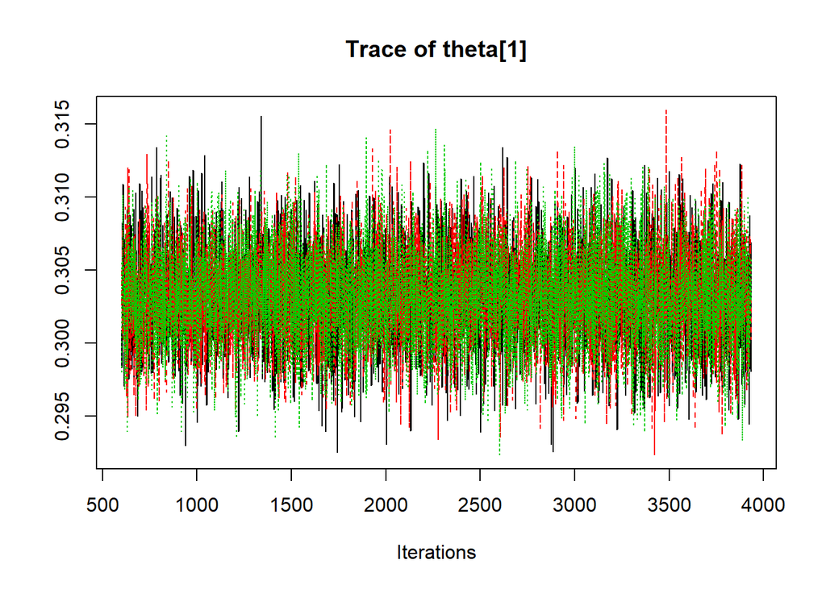

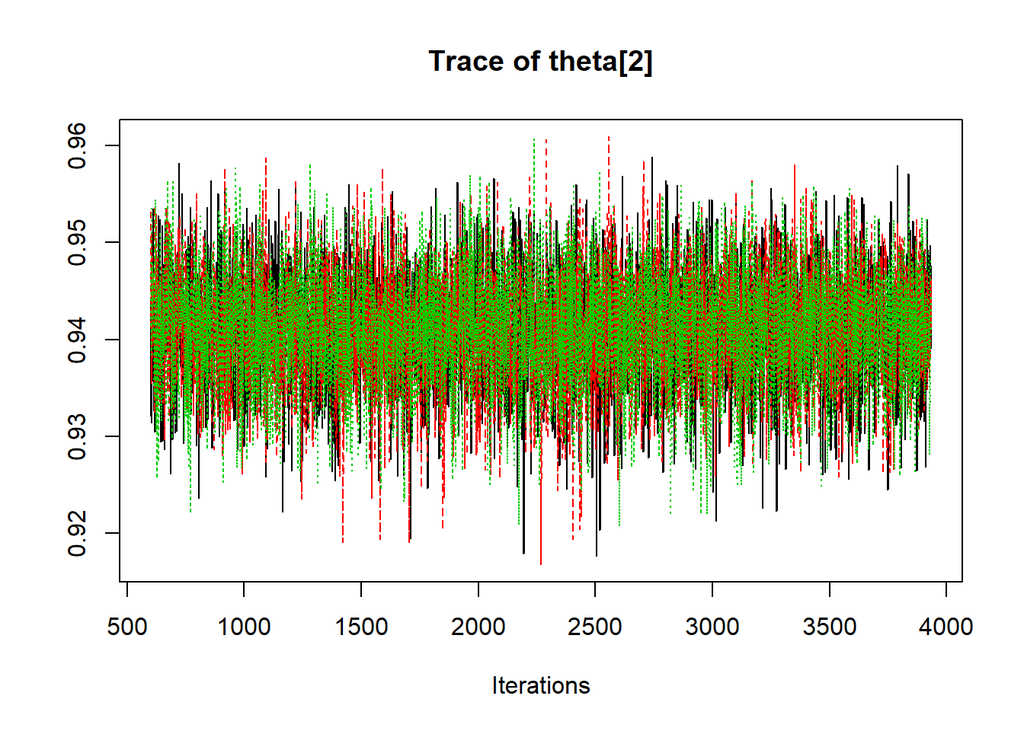

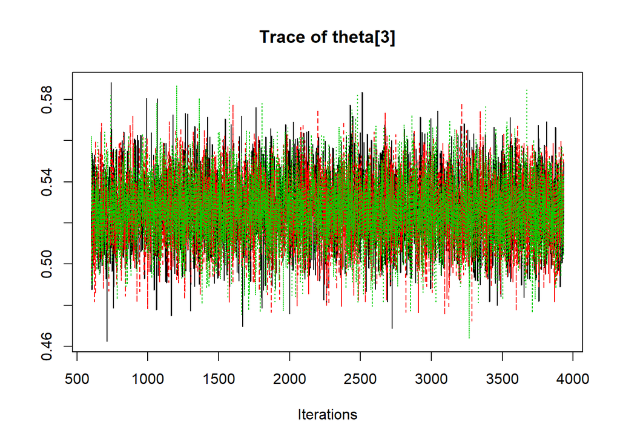

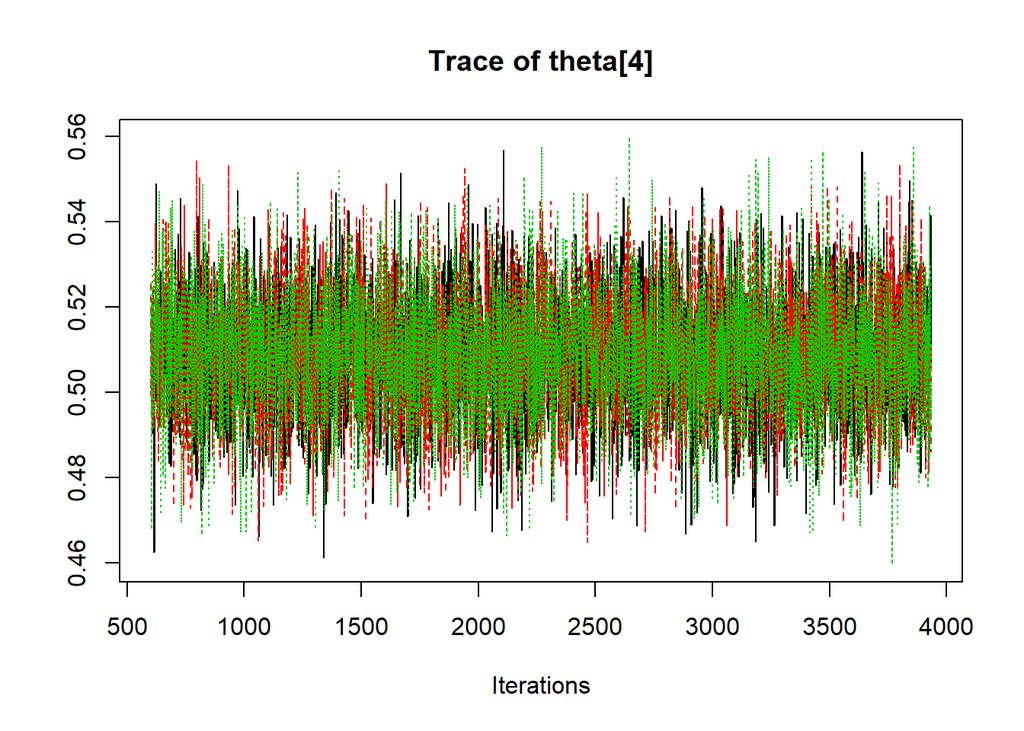

```r
coda::traceplot(codaSamples2)
```

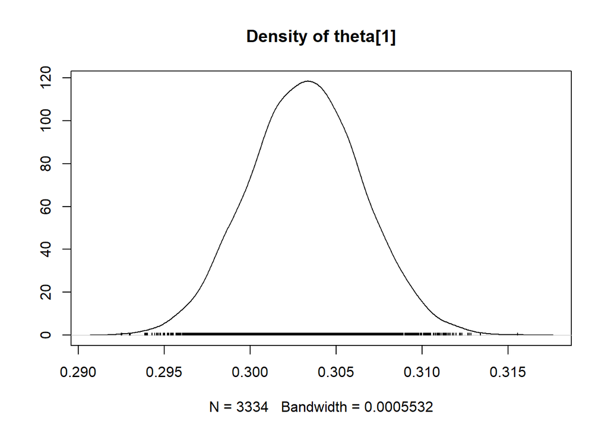

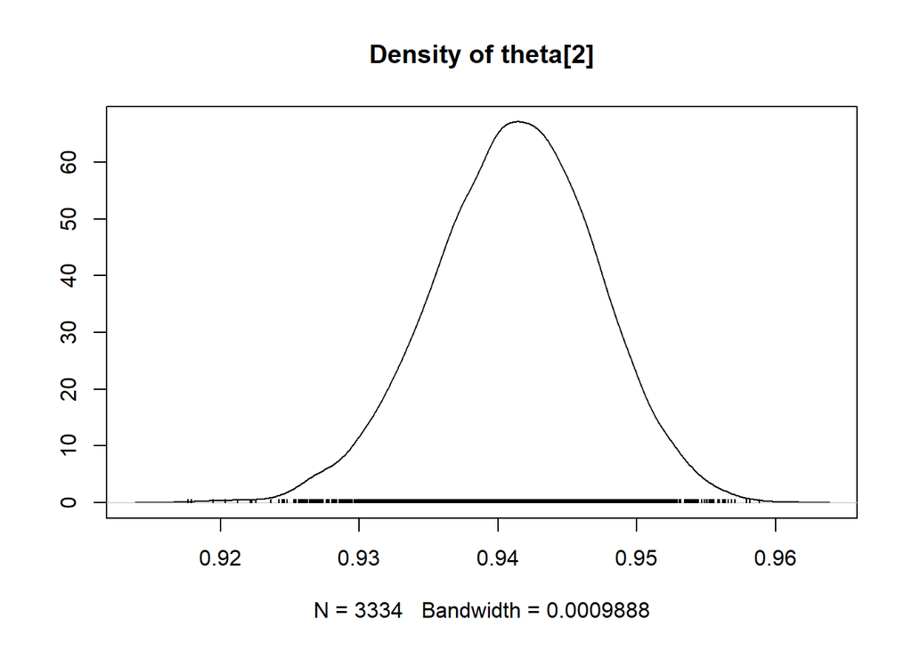

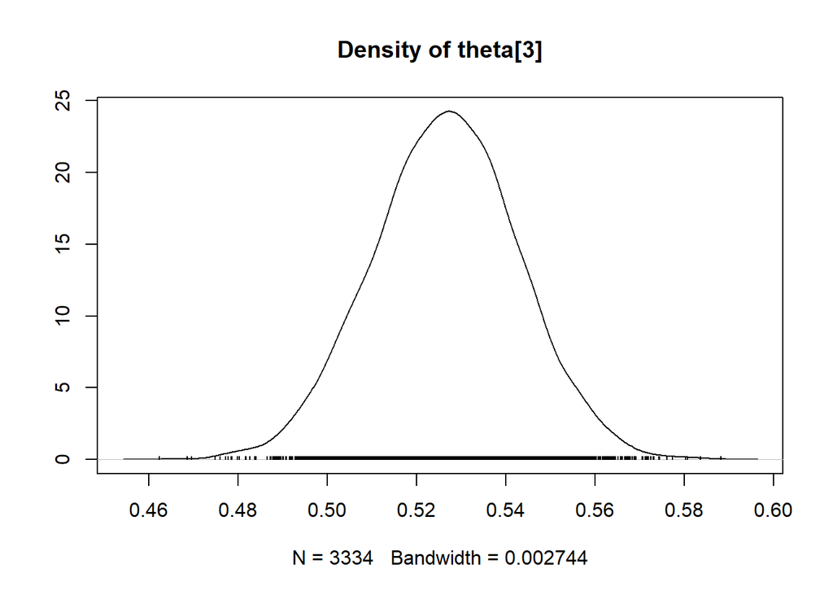

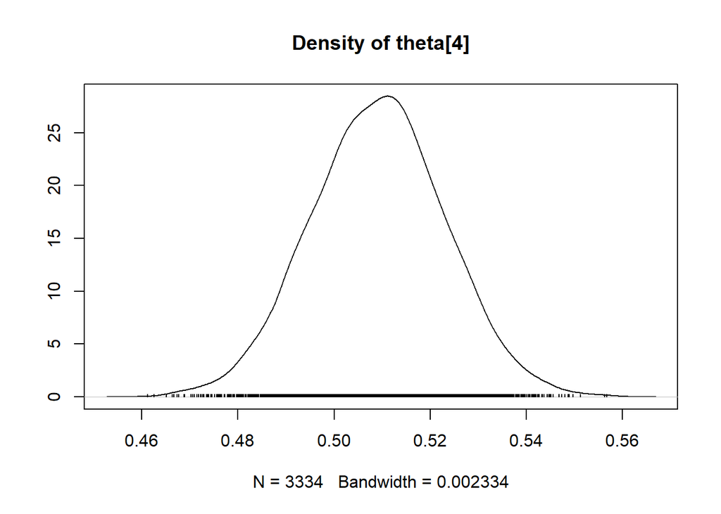

```r
densplot(codaSamples2)
```